# Model Performance Report

by Maggie Zhu - September 04, 2020 02:03 PM

# PD K-fold Cross Validation

In each fold of cross-validation, the sampled data are partitioned into training set and testing set. The analysis is on the training set, and validating the analysis on the testing set. The data partitions are different across the folds. The aim is to derive a more stable and accurate estimate of model prediction performance

## PD Model Coefficients / Significance

XXXX Coefficient NOT significant ($\alpha$=0.05)  
XXXX Fold coefficent $\ge$ 5% different from `coef_All`

Charge Off

| variable | coef_f1 | coef_f2 | coef_f3 | coef_f4 | coef_f5 | coef_All |
| --- | --- | --- | --- | --- | --- | --- |
| liquid_trans | -0.024 | -0.019 | 0.015 | -0.028 | 0.012 | 0.046 |

Prepayment

| variable | coef_f1 | coef_f2 | coef_f3 | coef_f4 | coef_f5 | coef_All |
| --- | --- | --- | --- | --- | --- | --- |
| Bal_Perc | -4.727 | -5.578 | -4.405 | -5.974 | -3.095 | 2.073 |
| liquid_trans | -0.048 | -0.091 | 0.139 | 0.111 | -0.146 | -0.219 |
| Member_Estimated_Income | -0.008 | -0.027 | -0.064 | 0.057 | -0.003 | 0.1 |
| Payments_Remaining | 0.014 | -0.018 | -0.021 | 0.01 | -0.033 | -0.064 |

## Concordance

Concordance is the fraction of pairs in the data, where the observation with the higher survival time has the higher probability of survival predicted by the model.

Charge Off

|  | 1 | 2 | 3 | 4 | 5 | All |
| --- | --- | --- | --- | --- | --- | --- |
| Concordance | 0.512 | 0.507 | 0.515 | 0.504 | 0.494 | 0.472 |
| Standard Error(C) | 0.023 | 0.023 | 0.023 | 0.024 | 0.024 | 0.012 |

Prepayment

|  | 1 | 2 | 3 | 4 | 5 | All |
| --- | --- | --- | --- | --- | --- | --- |
| Concordance | 0.804 | 0.887 | 0.842 | 0.876 | 0.844 | 0.743 |
| Standard Error(C) | 0.071 | 0.068 | 0.065 | 0.057 | 0.051 | 0.013 |

## Recalibration

For competing risk events (where the outcomes can be of more than 2 cagetories, such as default, active and prepaid), by aalen-johansen estimate, the probability of default could be over 1.0. Further recalibration is made with logistic regression modeling.

| Variable | Description | Estimate | is_Significant |
| --- | --- | --- | --- |
| (Intercept) | (Intercept) | 0.6852296 | TRUE |
| log(PD.CR.Unbound) | log(PD.CR.Unbound) | 1.1177993 | TRUE |

# PD Model Discrimination

## KS Tables

KS–The maximum separation between the percentage of events captured and percentage of non-events captured by the model in cumulative distributions of events and non-events. Values range from 0-1. Marked as red in the table, if any.

### 1

| DecileDown | Number of Chargedoff Accounts | Total Accounts | Number of Non-Chargedoff Accounts | DecileUp | Chargedoff Rate | Cumulative Chargedoff Rate | Non-Chargedoff Rate | Cumulative Non-Chargedoff Rate | KS | Time |
| --- | --- | --- | --- | --- | --- | --- | --- | --- | --- | --- |
| 10 | 59 | 116 | 57 | 1 | 10.95 | 10.95 | 9.18 | 9.18 | 1.77 | 1 |
| 9 | 48 | 116 | 68 | 2 | 8.91 | 19.86 | 10.95 | 20.13 | -0.27 | 1 |
| 8 | 53 | 116 | 63 | 3 | 9.83 | 29.69 | 10.14 | 30.27 | -0.58 | 1 |
| 7 | 49 | 116 | 67 | 4 | 9.09 | 38.78 | 10.79 | 41.06 | -2.28 | 1 |
| 6 | 56 | 116 | 60 | 5 | 10.39 | 49.17 | 9.66 | 50.72 | -1.55 | 1 |
| 5 | 62 | 116 | 54 | 6 | 11.50 | 60.67 | 8.70 | 59.42 | 1.25 | 1 |
| 4 | 46 | 116 | 70 | 7 | 8.53 | 69.20 | 11.27 | 70.69 | -1.49 | 1 |
| 3 | 59 | 116 | 57 | 8 | 10.95 | 80.15 | 9.18 | 79.87 | 0.28 | 1 |
| 2 | 58 | 116 | 58 | 9 | 10.76 | 90.91 | 9.34 | 89.21 | 1.7 | 1 |
| 1 | 49 | 116 | 67 | 10 | 9.09 | 100.00 | 10.79 | 100.00 | 0 | 1 |

### 2

| DecileDown | Number of Chargedoff Accounts | Total Accounts | Number of Non-Chargedoff Accounts | DecileUp | Chargedoff Rate | Cumulative Chargedoff Rate | Non-Chargedoff Rate | Cumulative Non-Chargedoff Rate | KS | Time |
| --- | --- | --- | --- | --- | --- | --- | --- | --- | --- | --- |
| 10 | 57 | 116 | 59 | 1 | 12.05 | 12.05 | 8.59 | 8.59 | 3.46 | 2 |
| 9 | 63 | 116 | 53 | 2 | 13.32 | 25.37 | 7.71 | 16.30 | 9.07 | 2 |
| 8 | 51 | 116 | 65 | 3 | 10.78 | 36.15 | 9.46 | 25.76 | 10.39 | 2 |
| 7 | 35 | 116 | 81 | 4 | 7.40 | 43.55 | 11.79 | 37.55 | 6 | 2 |
| 6 | 46 | 116 | 70 | 5 | 9.73 | 53.28 | 10.19 | 47.74 | 5.54 | 2 |
| 5 | 39 | 116 | 77 | 6 | 8.25 | 61.53 | 11.21 | 58.95 | 2.58 | 2 |
| 4 | 48 | 116 | 68 | 7 | 10.15 | 71.68 | 9.90 | 68.85 | 2.83 | 2 |
| 3 | 44 | 116 | 72 | 8 | 9.30 | 80.98 | 10.48 | 79.33 | 1.65 | 2 |
| 2 | 41 | 116 | 75 | 9 | 8.67 | 89.65 | 10.92 | 90.25 | -0.6 | 2 |
| 1 | 49 | 116 | 67 | 10 | 10.36 | 100.00 | 9.75 | 100.00 | 0.01 | 2 |

### 3

| DecileDown | Number of Chargedoff Accounts | Total Accounts | Number of Non-Chargedoff Accounts | DecileUp | Chargedoff Rate | Cumulative Chargedoff Rate | Non-Chargedoff Rate | Cumulative Non-Chargedoff Rate | KS | Time |
| --- | --- | --- | --- | --- | --- | --- | --- | --- | --- | --- |
| 10 | 6 | 116 | 110 | 1 | 21.43 | 21.43 | 9.72 | 9.72 | 11.71 | 3 |
| 9 | 2 | 116 | 114 | 2 | 7.14 | 28.57 | 10.07 | 19.79 | 8.78 | 3 |
| 8 | 2 | 116 | 114 | 3 | 7.14 | 35.71 | 10.07 | 29.86 | 5.85 | 3 |
| 7 | 1 | 116 | 115 | 4 | 3.57 | 39.28 | 10.16 | 40.02 | -0.74 | 3 |
| 6 | 3 | 116 | 113 | 5 | 10.71 | 49.99 | 9.98 | 50.00 | -0.01 | 3 |
| 5 | 4 | 116 | 112 | 6 | 14.29 | 64.28 | 9.89 | 59.89 | 4.39 | 3 |
| 4 | 2 | 116 | 114 | 7 | 7.14 | 71.42 | 10.07 | 69.96 | 1.46 | 3 |
| 3 | 3 | 116 | 113 | 8 | 10.71 | 82.13 | 9.98 | 79.94 | 2.19 | 3 |
| 2 | 1 | 116 | 115 | 9 | 3.57 | 85.70 | 10.16 | 90.10 | -4.4 | 3 |
| 1 | 4 | 116 | 112 | 10 | 14.29 | 99.99 | 9.89 | 99.99 | 0 | 3 |

### 4

| DecileDown | Number of Chargedoff Accounts | Total Accounts | Number of Non-Chargedoff Accounts | DecileUp | Chargedoff Rate | Cumulative Chargedoff Rate | Non-Chargedoff Rate | Cumulative Non-Chargedoff Rate | KS | Time |
| --- | --- | --- | --- | --- | --- | --- | --- | --- | --- | --- |
| 10 | 1 | 116 | 115 | 1 | 7.69 | 7.69 | 10.03 | 10.03 | -2.34 | 4 |
| 9 | 1 | 116 | 115 | 2 | 7.69 | 15.38 | 10.03 | 20.06 | -4.68 | 4 |
| 8 | 1 | 116 | 115 | 3 | 7.69 | 23.07 | 10.03 | 30.09 | -7.02 | 4 |
| 7 | 1 | 116 | 115 | 4 | 7.69 | 30.76 | 10.03 | 40.12 | -9.36 | 4 |
| 6 | 4 | 116 | 112 | 5 | 30.77 | 61.53 | 9.76 | 49.88 | 11.65 | 4 |
| 5 | 0 | 116 | 116 | 6 | 0.00 | 61.53 | 10.11 | 59.99 | 1.54 | 4 |
| 4 | 1 | 116 | 115 | 7 | 7.69 | 69.22 | 10.03 | 70.02 | -0.8 | 4 |
| 3 | 1 | 116 | 115 | 8 | 7.69 | 76.91 | 10.03 | 80.05 | -3.14 | 4 |
| 2 | 2 | 116 | 114 | 9 | 15.38 | 92.29 | 9.94 | 89.99 | 2.3 | 4 |
| 1 | 1 | 116 | 115 | 10 | 7.69 | 99.98 | 10.03 | 100.00 | -0.04 | 4 |

### 5

| DecileDown | Number of Chargedoff Accounts | Total Accounts | Number of Non-Chargedoff Accounts | DecileUp | Chargedoff Rate | Cumulative Chargedoff Rate | Non-Chargedoff Rate | Cumulative Non-Chargedoff Rate | KS | Time |
| --- | --- | --- | --- | --- | --- | --- | --- | --- | --- | --- |
| 10 | 1 | 116 | 115 | 1 | 16.67 | 16.67 | 9.97 | 9.97 | 6.7 | 5 |
| 9 | 0 | 116 | 116 | 2 | 0.00 | 16.67 | 10.05 | 20.02 | -3.35 | 5 |
| 8 | 1 | 116 | 115 | 3 | 16.67 | 33.34 | 9.97 | 29.99 | 3.35 | 5 |
| 7 | 0 | 116 | 116 | 4 | 0.00 | 33.34 | 10.05 | 40.04 | -6.7 | 5 |
| 6 | 0 | 116 | 116 | 5 | 0.00 | 33.34 | 10.05 | 50.09 | -16.75 | 5 |
| 5 | 4 | 116 | 112 | 6 | 66.67 | 100.00 | 9.71 | 59.80 | 40.21 | 5 |
| 4 | 0 | 116 | 116 | 7 | 0.00 | 100.00 | 10.05 | 69.85 | 30.16 | 5 |
| 3 | 0 | 116 | 116 | 8 | 0.00 | 100.00 | 10.05 | 79.90 | 20.11 | 5 |
| 2 | 0 | 116 | 116 | 9 | 0.00 | 100.00 | 10.05 | 89.95 | 10.06 | 5 |
| 1 | 0 | 116 | 116 | 10 | 0.00 | 100.00 | 10.05 | 100.00 | 0.01 | 5 |

### 6

| DecileDown | Number of Chargedoff Accounts | Total Accounts | Number of Non-Chargedoff Accounts | DecileUp | Chargedoff Rate | Cumulative Chargedoff Rate | Non-Chargedoff Rate | Cumulative Non-Chargedoff Rate | KS | Time |
| --- | --- | --- | --- | --- | --- | --- | --- | --- | --- | --- |
| 10 | 0 | 116 | 116 | 1 | NaN | NaN | 10 | 10 | NA | 6 |
| 9 | 0 | 116 | 116 | 2 | NaN | NaN | 10 | 20 | NA | 6 |
| 8 | 0 | 116 | 116 | 3 | NaN | NaN | 10 | 30 | NA | 6 |
| 7 | 0 | 116 | 116 | 4 | NaN | NaN | 10 | 40 | NA | 6 |
| 6 | 0 | 116 | 116 | 5 | NaN | NaN | 10 | 50 | NA | 6 |
| 5 | 0 | 116 | 116 | 6 | NaN | NaN | 10 | 60 | NA | 6 |
| 4 | 0 | 116 | 116 | 7 | NaN | NaN | 10 | 70 | NA | 6 |
| 3 | 0 | 116 | 116 | 8 | NaN | NaN | 10 | 80 | NA | 6 |
| 2 | 0 | 116 | 116 | 9 | NaN | NaN | 10 | 90 | NA | 6 |
| 1 | 0 | 116 | 116 | 10 | NaN | NaN | 10 | 100 | NA | 6 |

### 7

| DecileDown | Number of Chargedoff Accounts | Total Accounts | Number of Non-Chargedoff Accounts | DecileUp | Chargedoff Rate | Cumulative Chargedoff Rate | Non-Chargedoff Rate | Cumulative Non-Chargedoff Rate | KS | Time |
| --- | --- | --- | --- | --- | --- | --- | --- | --- | --- | --- |
| 10 | 1 | 116 | 115 | 1 | 33.33 | 33.33 | 9.94 | 9.94 | 23.39 | 7 |
| 9 | 0 | 116 | 116 | 2 | 0.00 | 33.33 | 10.03 | 19.97 | 13.36 | 7 |
| 8 | 0 | 116 | 116 | 3 | 0.00 | 33.33 | 10.03 | 30.00 | 3.33 | 7 |
| 7 | 1 | 116 | 115 | 4 | 33.33 | 66.66 | 9.94 | 39.94 | 26.72 | 7 |
| 6 | 1 | 116 | 115 | 5 | 33.33 | 99.99 | 9.94 | 49.88 | 50.11 | 7 |
| 5 | 0 | 116 | 116 | 6 | 0.00 | 99.99 | 10.03 | 59.91 | 40.08 | 7 |
| 4 | 0 | 116 | 116 | 7 | 0.00 | 99.99 | 10.03 | 69.94 | 30.05 | 7 |
| 3 | 0 | 116 | 116 | 8 | 0.00 | 99.99 | 10.03 | 79.97 | 20.02 | 7 |
| 2 | 0 | 116 | 116 | 9 | 0.00 | 99.99 | 10.03 | 90.00 | 9.99 | 7 |
| 1 | 0 | 116 | 116 | 10 | 0.00 | 99.99 | 10.03 | 100.00 | -0.04 | 7 |

### 8

| DecileDown | Number of Chargedoff Accounts | Total Accounts | Number of Non-Chargedoff Accounts | DecileUp | Chargedoff Rate | Cumulative Chargedoff Rate | Non-Chargedoff Rate | Cumulative Non-Chargedoff Rate | KS | Time |
| --- | --- | --- | --- | --- | --- | --- | --- | --- | --- | --- |
| 10 | 2 | 116 | 114 | 1 | 28.57 | 28.57 | 9.89 | 9.89 | 18.68 | 8 |
| 9 | 0 | 116 | 116 | 2 | 0.00 | 28.57 | 10.06 | 19.95 | 8.62 | 8 |
| 8 | 0 | 116 | 116 | 3 | 0.00 | 28.57 | 10.06 | 30.01 | -1.44 | 8 |
| 7 | 0 | 116 | 116 | 4 | 0.00 | 28.57 | 10.06 | 40.07 | -11.5 | 8 |
| 6 | 0 | 116 | 116 | 5 | 0.00 | 28.57 | 10.06 | 50.13 | -21.56 | 8 |
| 5 | 0 | 116 | 116 | 6 | 0.00 | 28.57 | 10.06 | 60.19 | -31.62 | 8 |
| 4 | 1 | 116 | 115 | 7 | 14.29 | 42.86 | 9.97 | 70.16 | -27.3 | 8 |
| 3 | 2 | 116 | 114 | 8 | 28.57 | 71.43 | 9.89 | 80.05 | -8.62 | 8 |
| 2 | 1 | 116 | 115 | 9 | 14.29 | 85.72 | 9.97 | 90.02 | -4.3 | 8 |
| 1 | 1 | 116 | 115 | 10 | 14.29 | 100.00 | 9.97 | 99.99 | 0.02 | 8 |

### 9

| DecileDown | Number of Chargedoff Accounts | Total Accounts | Number of Non-Chargedoff Accounts | DecileUp | Chargedoff Rate | Cumulative Chargedoff Rate | Non-Chargedoff Rate | Cumulative Non-Chargedoff Rate | KS | Time |
| --- | --- | --- | --- | --- | --- | --- | --- | --- | --- | --- |
| 10 | 2 | 116 | 114 | 1 | 50 | 50 | 9.86 | 9.86 | 40.14 | 9 |
| 9 | 0 | 116 | 116 | 2 | 0 | 50 | 10.03 | 19.89 | 30.11 | 9 |
| 8 | 1 | 116 | 115 | 3 | 25 | 75 | 9.95 | 29.84 | 45.16 | 9 |
| 7 | 0 | 116 | 116 | 4 | 0 | 75 | 10.03 | 39.87 | 35.13 | 9 |
| 6 | 0 | 116 | 116 | 5 | 0 | 75 | 10.03 | 49.90 | 25.1 | 9 |
| 5 | 0 | 116 | 116 | 6 | 0 | 75 | 10.03 | 59.93 | 15.07 | 9 |
| 4 | 0 | 116 | 116 | 7 | 0 | 75 | 10.03 | 69.96 | 5.04 | 9 |
| 3 | 1 | 116 | 115 | 8 | 25 | 100 | 9.95 | 79.91 | 20.09 | 9 |
| 2 | 0 | 116 | 116 | 9 | 0 | 100 | 10.03 | 89.94 | 10.06 | 9 |
| 1 | 0 | 116 | 116 | 10 | 0 | 100 | 10.03 | 99.97 | 0.03 | 9 |

### 10

| DecileDown | Number of Chargedoff Accounts | Total Accounts | Number of Non-Chargedoff Accounts | DecileUp | Chargedoff Rate | Cumulative Chargedoff Rate | Non-Chargedoff Rate | Cumulative Non-Chargedoff Rate | KS | Time |
| --- | --- | --- | --- | --- | --- | --- | --- | --- | --- | --- |
| 10 | 0 | 116 | 116 | 1 | 0.00 | 0.00 | 10.03 | 10.03 | -10.03 | 10 |
| 9 | 1 | 116 | 115 | 2 | 33.33 | 33.33 | 9.94 | 19.97 | 13.36 | 10 |
| 8 | 0 | 116 | 116 | 3 | 0.00 | 33.33 | 10.03 | 30.00 | 3.33 | 10 |
| 7 | 0 | 116 | 116 | 4 | 0.00 | 33.33 | 10.03 | 40.03 | -6.7 | 10 |
| 6 | 0 | 116 | 116 | 5 | 0.00 | 33.33 | 10.03 | 50.06 | -16.73 | 10 |
| 5 | 1 | 116 | 115 | 6 | 33.33 | 66.66 | 9.94 | 60.00 | 6.66 | 10 |
| 4 | 0 | 116 | 116 | 7 | 0.00 | 66.66 | 10.03 | 70.03 | -3.37 | 10 |
| 3 | 1 | 116 | 115 | 8 | 33.33 | 99.99 | 9.94 | 79.97 | 20.02 | 10 |
| 2 | 0 | 116 | 116 | 9 | 0.00 | 99.99 | 10.03 | 90.00 | 9.99 | 10 |
| 1 | 0 | 116 | 116 | 10 | 0.00 | 99.99 | 10.03 | 100.00 | -0.04 | 10 |

### 11

| DecileDown | Number of Chargedoff Accounts | Total Accounts | Number of Non-Chargedoff Accounts | DecileUp | Chargedoff Rate | Cumulative Chargedoff Rate | Non-Chargedoff Rate | Cumulative Non-Chargedoff Rate | KS | Time |
| --- | --- | --- | --- | --- | --- | --- | --- | --- | --- | --- |
| 10 | 0 | 116 | 116 | 1 | 0 | 0 | 10.02 | 10.02 | -10.02 | 11 |
| 9 | 0 | 116 | 116 | 2 | 0 | 0 | 10.02 | 20.04 | -20.04 | 11 |
| 8 | 0 | 116 | 116 | 3 | 0 | 0 | 10.02 | 30.06 | -30.06 | 11 |
| 7 | 0 | 116 | 116 | 4 | 0 | 0 | 10.02 | 40.08 | -40.08 | 11 |
| 6 | 0 | 116 | 116 | 5 | 0 | 0 | 10.02 | 50.10 | -50.1 | 11 |
| 5 | 0 | 116 | 116 | 6 | 0 | 0 | 10.02 | 60.12 | -60.12 | 11 |
| 4 | 2 | 116 | 114 | 7 | 100 | 100 | 9.84 | 69.96 | 30.04 | 11 |
| 3 | 0 | 116 | 116 | 8 | 0 | 100 | 10.02 | 79.98 | 20.02 | 11 |
| 2 | 0 | 116 | 116 | 9 | 0 | 100 | 10.02 | 90.00 | 10 | 11 |
| 1 | 0 | 116 | 116 | 10 | 0 | 100 | 10.02 | 100.00 | -0.02 | 11 |

### 12

| DecileDown | Number of Chargedoff Accounts | Total Accounts | Number of Non-Chargedoff Accounts | DecileUp | Chargedoff Rate | Cumulative Chargedoff Rate | Non-Chargedoff Rate | Cumulative Non-Chargedoff Rate | KS | Time |
| --- | --- | --- | --- | --- | --- | --- | --- | --- | --- | --- |
| 10 | 1 | 116 | 115 | 1 | 20 | 20 | 9.96 | 9.96 | 10.04 | 12 |
| 9 | 2 | 116 | 114 | 2 | 40 | 60 | 9.87 | 19.83 | 40.17 | 12 |
| 8 | 0 | 116 | 116 | 3 | 0 | 60 | 10.04 | 29.87 | 30.13 | 12 |
| 7 | 0 | 116 | 116 | 4 | 0 | 60 | 10.04 | 39.91 | 20.09 | 12 |
| 6 | 1 | 116 | 115 | 5 | 20 | 80 | 9.96 | 49.87 | 30.13 | 12 |
| 5 | 0 | 116 | 116 | 6 | 0 | 80 | 10.04 | 59.91 | 20.09 | 12 |
| 4 | 0 | 116 | 116 | 7 | 0 | 80 | 10.04 | 69.95 | 10.05 | 12 |
| 3 | 1 | 116 | 115 | 8 | 20 | 100 | 9.96 | 79.91 | 20.09 | 12 |
| 2 | 0 | 116 | 116 | 9 | 0 | 100 | 10.04 | 89.95 | 10.05 | 12 |
| 1 | 0 | 116 | 116 | 10 | 0 | 100 | 10.04 | 99.99 | 0.01 | 12 |

### 13

| DecileDown | Number of Chargedoff Accounts | Total Accounts | Number of Non-Chargedoff Accounts | DecileUp | Chargedoff Rate | Cumulative Chargedoff Rate | Non-Chargedoff Rate | Cumulative Non-Chargedoff Rate | KS | Time |
| --- | --- | --- | --- | --- | --- | --- | --- | --- | --- | --- |
| 10 | 0 | 116 | 116 | 1 | 0 | 0 | 10.02 | 10.02 | -10.02 | 13 |
| 9 | 0 | 116 | 116 | 2 | 0 | 0 | 10.02 | 20.04 | -20.04 | 13 |
| 8 | 0 | 116 | 116 | 3 | 0 | 0 | 10.02 | 30.06 | -30.06 | 13 |
| 7 | 0 | 116 | 116 | 4 | 0 | 0 | 10.02 | 40.08 | -40.08 | 13 |
| 6 | 0 | 116 | 116 | 5 | 0 | 0 | 10.02 | 50.10 | -50.1 | 13 |
| 5 | 1 | 116 | 115 | 6 | 50 | 50 | 9.93 | 60.03 | -10.03 | 13 |
| 4 | 0 | 116 | 116 | 7 | 0 | 50 | 10.02 | 70.05 | -20.05 | 13 |
| 3 | 0 | 116 | 116 | 8 | 0 | 50 | 10.02 | 80.07 | -30.07 | 13 |
| 2 | 1 | 116 | 115 | 9 | 50 | 100 | 9.93 | 90.00 | 10 | 13 |
| 1 | 0 | 116 | 116 | 10 | 0 | 100 | 10.02 | 100.00 | -0.02 | 13 |

### 14

| DecileDown | Number of Chargedoff Accounts | Total Accounts | Number of Non-Chargedoff Accounts | DecileUp | Chargedoff Rate | Cumulative Chargedoff Rate | Non-Chargedoff Rate | Cumulative Non-Chargedoff Rate | KS | Time |
| --- | --- | --- | --- | --- | --- | --- | --- | --- | --- | --- |
| 10 | 0 | 116 | 116 | 1 | 0.00 | 0.00 | 10.03 | 10.03 | -10.03 | 14 |
| 9 | 0 | 116 | 116 | 2 | 0.00 | 0.00 | 10.03 | 20.06 | -20.06 | 14 |
| 8 | 0 | 116 | 116 | 3 | 0.00 | 0.00 | 10.03 | 30.09 | -30.09 | 14 |
| 7 | 1 | 116 | 115 | 4 | 33.33 | 33.33 | 9.94 | 40.03 | -6.7 | 14 |
| 6 | 0 | 116 | 116 | 5 | 0.00 | 33.33 | 10.03 | 50.06 | -16.73 | 14 |
| 5 | 0 | 116 | 116 | 6 | 0.00 | 33.33 | 10.03 | 60.09 | -26.76 | 14 |
| 4 | 0 | 116 | 116 | 7 | 0.00 | 33.33 | 10.03 | 70.12 | -36.79 | 14 |
| 3 | 0 | 116 | 116 | 8 | 0.00 | 33.33 | 10.03 | 80.15 | -46.82 | 14 |
| 2 | 1 | 116 | 115 | 9 | 33.33 | 66.66 | 9.94 | 90.09 | -23.43 | 14 |
| 1 | 1 | 116 | 115 | 10 | 33.33 | 99.99 | 9.94 | 100.00 | -0.04 | 14 |

### 15

| DecileDown | Number of Chargedoff Accounts | Total Accounts | Number of Non-Chargedoff Accounts | DecileUp | Chargedoff Rate | Cumulative Chargedoff Rate | Non-Chargedoff Rate | Cumulative Non-Chargedoff Rate | KS | Time |
| --- | --- | --- | --- | --- | --- | --- | --- | --- | --- | --- |
| 10 | 0 | 116 | 116 | 1 | NaN | NaN | 10 | 10 | NA | 15 |
| 9 | 0 | 116 | 116 | 2 | NaN | NaN | 10 | 20 | NA | 15 |
| 8 | 0 | 116 | 116 | 3 | NaN | NaN | 10 | 30 | NA | 15 |
| 7 | 0 | 116 | 116 | 4 | NaN | NaN | 10 | 40 | NA | 15 |
| 6 | 0 | 116 | 116 | 5 | NaN | NaN | 10 | 50 | NA | 15 |
| 5 | 0 | 116 | 116 | 6 | NaN | NaN | 10 | 60 | NA | 15 |
| 4 | 0 | 116 | 116 | 7 | NaN | NaN | 10 | 70 | NA | 15 |
| 3 | 0 | 116 | 116 | 8 | NaN | NaN | 10 | 80 | NA | 15 |
| 2 | 0 | 116 | 116 | 9 | NaN | NaN | 10 | 90 | NA | 15 |
| 1 | 0 | 116 | 116 | 10 | NaN | NaN | 10 | 100 | NA | 15 |

### 16

| DecileDown | Number of Chargedoff Accounts | Total Accounts | Number of Non-Chargedoff Accounts | DecileUp | Chargedoff Rate | Cumulative Chargedoff Rate | Non-Chargedoff Rate | Cumulative Non-Chargedoff Rate | KS | Time |
| --- | --- | --- | --- | --- | --- | --- | --- | --- | --- | --- |
| 10 | 0 | 116 | 116 | 1 | NaN | NaN | 10 | 10 | NA | 16 |
| 9 | 0 | 116 | 116 | 2 | NaN | NaN | 10 | 20 | NA | 16 |
| 8 | 0 | 116 | 116 | 3 | NaN | NaN | 10 | 30 | NA | 16 |
| 7 | 0 | 116 | 116 | 4 | NaN | NaN | 10 | 40 | NA | 16 |
| 6 | 0 | 116 | 116 | 5 | NaN | NaN | 10 | 50 | NA | 16 |
| 5 | 0 | 116 | 116 | 6 | NaN | NaN | 10 | 60 | NA | 16 |
| 4 | 0 | 116 | 116 | 7 | NaN | NaN | 10 | 70 | NA | 16 |
| 3 | 0 | 116 | 116 | 8 | NaN | NaN | 10 | 80 | NA | 16 |
| 2 | 0 | 116 | 116 | 9 | NaN | NaN | 10 | 90 | NA | 16 |
| 1 | 0 | 116 | 116 | 10 | NaN | NaN | 10 | 100 | NA | 16 |

### 17

| DecileDown | Number of Chargedoff Accounts | Total Accounts | Number of Non-Chargedoff Accounts | DecileUp | Chargedoff Rate | Cumulative Chargedoff Rate | Non-Chargedoff Rate | Cumulative Non-Chargedoff Rate | KS | Time |
| --- | --- | --- | --- | --- | --- | --- | --- | --- | --- | --- |
| 10 | 0 | 116 | 116 | 1 | 0 | 0 | 10.01 | 10.01 | -10.01 | 17 |
| 9 | 0 | 116 | 116 | 2 | 0 | 0 | 10.01 | 20.02 | -20.02 | 17 |
| 8 | 0 | 116 | 116 | 3 | 0 | 0 | 10.01 | 30.03 | -30.03 | 17 |
| 7 | 0 | 116 | 116 | 4 | 0 | 0 | 10.01 | 40.04 | -40.04 | 17 |
| 6 | 0 | 116 | 116 | 5 | 0 | 0 | 10.01 | 50.05 | -50.05 | 17 |
| 5 | 0 | 116 | 116 | 6 | 0 | 0 | 10.01 | 60.06 | -60.06 | 17 |
| 4 | 1 | 116 | 115 | 7 | 100 | 100 | 9.92 | 69.98 | 30.02 | 17 |
| 3 | 0 | 116 | 116 | 8 | 0 | 100 | 10.01 | 79.99 | 20.01 | 17 |
| 2 | 0 | 116 | 116 | 9 | 0 | 100 | 10.01 | 90.00 | 10 | 17 |
| 1 | 0 | 116 | 116 | 10 | 0 | 100 | 10.01 | 100.00 | -0.01 | 17 |

### 18

| DecileDown | Number of Chargedoff Accounts | Total Accounts | Number of Non-Chargedoff Accounts | DecileUp | Chargedoff Rate | Cumulative Chargedoff Rate | Non-Chargedoff Rate | Cumulative Non-Chargedoff Rate | KS | Time |
| --- | --- | --- | --- | --- | --- | --- | --- | --- | --- | --- |
| 10 | 0 | 116 | 116 | 1 | NaN | NaN | 10 | 10 | NA | 18 |
| 9 | 0 | 116 | 116 | 2 | NaN | NaN | 10 | 20 | NA | 18 |
| 8 | 0 | 116 | 116 | 3 | NaN | NaN | 10 | 30 | NA | 18 |
| 7 | 0 | 116 | 116 | 4 | NaN | NaN | 10 | 40 | NA | 18 |
| 6 | 0 | 116 | 116 | 5 | NaN | NaN | 10 | 50 | NA | 18 |
| 5 | 0 | 116 | 116 | 6 | NaN | NaN | 10 | 60 | NA | 18 |
| 4 | 0 | 116 | 116 | 7 | NaN | NaN | 10 | 70 | NA | 18 |
| 3 | 0 | 116 | 116 | 8 | NaN | NaN | 10 | 80 | NA | 18 |
| 2 | 0 | 116 | 116 | 9 | NaN | NaN | 10 | 90 | NA | 18 |
| 1 | 0 | 116 | 116 | 10 | NaN | NaN | 10 | 100 | NA | 18 |

### 19

| DecileDown | Number of Chargedoff Accounts | Total Accounts | Number of Non-Chargedoff Accounts | DecileUp | Chargedoff Rate | Cumulative Chargedoff Rate | Non-Chargedoff Rate | Cumulative Non-Chargedoff Rate | KS | Time |
| --- | --- | --- | --- | --- | --- | --- | --- | --- | --- | --- |
| 10 | 0 | 116 | 116 | 1 | NaN | NaN | 10 | 10 | NA | 19 |
| 9 | 0 | 116 | 116 | 2 | NaN | NaN | 10 | 20 | NA | 19 |
| 8 | 0 | 116 | 116 | 3 | NaN | NaN | 10 | 30 | NA | 19 |
| 7 | 0 | 116 | 116 | 4 | NaN | NaN | 10 | 40 | NA | 19 |
| 6 | 0 | 116 | 116 | 5 | NaN | NaN | 10 | 50 | NA | 19 |
| 5 | 0 | 116 | 116 | 6 | NaN | NaN | 10 | 60 | NA | 19 |
| 4 | 0 | 116 | 116 | 7 | NaN | NaN | 10 | 70 | NA | 19 |
| 3 | 0 | 116 | 116 | 8 | NaN | NaN | 10 | 80 | NA | 19 |
| 2 | 0 | 116 | 116 | 9 | NaN | NaN | 10 | 90 | NA | 19 |
| 1 | 0 | 116 | 116 | 10 | NaN | NaN | 10 | 100 | NA | 19 |

### 20

| DecileDown | Number of Chargedoff Accounts | Total Accounts | Number of Non-Chargedoff Accounts | DecileUp | Chargedoff Rate | Cumulative Chargedoff Rate | Non-Chargedoff Rate | Cumulative Non-Chargedoff Rate | KS | Time |
| --- | --- | --- | --- | --- | --- | --- | --- | --- | --- | --- |
| 10 | 0 | 116 | 116 | 1 | 0 | 0 | 10.01 | 10.01 | -10.01 | 20 |
| 9 | 0 | 116 | 116 | 2 | 0 | 0 | 10.01 | 20.02 | -20.02 | 20 |
| 8 | 0 | 116 | 116 | 3 | 0 | 0 | 10.01 | 30.03 | -30.03 | 20 |
| 7 | 0 | 116 | 116 | 4 | 0 | 0 | 10.01 | 40.04 | -40.04 | 20 |
| 6 | 0 | 116 | 116 | 5 | 0 | 0 | 10.01 | 50.05 | -50.05 | 20 |
| 5 | 0 | 116 | 116 | 6 | 0 | 0 | 10.01 | 60.06 | -60.06 | 20 |
| 4 | 1 | 116 | 115 | 7 | 100 | 100 | 9.92 | 69.98 | 30.02 | 20 |
| 3 | 0 | 116 | 116 | 8 | 0 | 100 | 10.01 | 79.99 | 20.01 | 20 |
| 2 | 0 | 116 | 116 | 9 | 0 | 100 | 10.01 | 90.00 | 10 | 20 |
| 1 | 0 | 116 | 116 | 10 | 0 | 100 | 10.01 | 100.00 | -0.01 | 20 |

### 21

| DecileDown | Number of Chargedoff Accounts | Total Accounts | Number of Non-Chargedoff Accounts | DecileUp | Chargedoff Rate | Cumulative Chargedoff Rate | Non-Chargedoff Rate | Cumulative Non-Chargedoff Rate | KS | Time |
| --- | --- | --- | --- | --- | --- | --- | --- | --- | --- | --- |
| 10 | 0 | 116 | 116 | 1 | NaN | NaN | 10 | 10 | NA | 21 |
| 9 | 0 | 116 | 116 | 2 | NaN | NaN | 10 | 20 | NA | 21 |
| 8 | 0 | 116 | 116 | 3 | NaN | NaN | 10 | 30 | NA | 21 |
| 7 | 0 | 116 | 116 | 4 | NaN | NaN | 10 | 40 | NA | 21 |
| 6 | 0 | 116 | 116 | 5 | NaN | NaN | 10 | 50 | NA | 21 |
| 5 | 0 | 116 | 116 | 6 | NaN | NaN | 10 | 60 | NA | 21 |
| 4 | 0 | 116 | 116 | 7 | NaN | NaN | 10 | 70 | NA | 21 |
| 3 | 0 | 116 | 116 | 8 | NaN | NaN | 10 | 80 | NA | 21 |
| 2 | 0 | 116 | 116 | 9 | NaN | NaN | 10 | 90 | NA | 21 |
| 1 | 0 | 116 | 116 | 10 | NaN | NaN | 10 | 100 | NA | 21 |

### 22

| DecileDown | Number of Chargedoff Accounts | Total Accounts | Number of Non-Chargedoff Accounts | DecileUp | Chargedoff Rate | Cumulative Chargedoff Rate | Non-Chargedoff Rate | Cumulative Non-Chargedoff Rate | KS | Time |
| --- | --- | --- | --- | --- | --- | --- | --- | --- | --- | --- |
| 10 | 0 | 116 | 116 | 1 | 0 | 0 | 10.01 | 10.01 | -10.01 | 22 |
| 9 | 0 | 116 | 116 | 2 | 0 | 0 | 10.01 | 20.02 | -20.02 | 22 |
| 8 | 0 | 116 | 116 | 3 | 0 | 0 | 10.01 | 30.03 | -30.03 | 22 |
| 7 | 0 | 116 | 116 | 4 | 0 | 0 | 10.01 | 40.04 | -40.04 | 22 |
| 6 | 0 | 116 | 116 | 5 | 0 | 0 | 10.01 | 50.05 | -50.05 | 22 |
| 5 | 0 | 116 | 116 | 6 | 0 | 0 | 10.01 | 60.06 | -60.06 | 22 |
| 4 | 0 | 116 | 116 | 7 | 0 | 0 | 10.01 | 70.07 | -70.07 | 22 |
| 3 | 0 | 116 | 116 | 8 | 0 | 0 | 10.01 | 80.08 | -80.08 | 22 |
| 2 | 0 | 116 | 116 | 9 | 0 | 0 | 10.01 | 90.09 | -90.09 | 22 |
| 1 | 1 | 116 | 115 | 10 | 100 | 100 | 9.92 | 100.00 | -0.01 | 22 |

### 23

| DecileDown | Number of Chargedoff Accounts | Total Accounts | Number of Non-Chargedoff Accounts | DecileUp | Chargedoff Rate | Cumulative Chargedoff Rate | Non-Chargedoff Rate | Cumulative Non-Chargedoff Rate | KS | Time |
| --- | --- | --- | --- | --- | --- | --- | --- | --- | --- | --- |
| 10 | 0 | 116 | 116 | 1 | NaN | NaN | 10 | 10 | NA | 23 |
| 9 | 0 | 116 | 116 | 2 | NaN | NaN | 10 | 20 | NA | 23 |
| 8 | 0 | 116 | 116 | 3 | NaN | NaN | 10 | 30 | NA | 23 |
| 7 | 0 | 116 | 116 | 4 | NaN | NaN | 10 | 40 | NA | 23 |
| 6 | 0 | 116 | 116 | 5 | NaN | NaN | 10 | 50 | NA | 23 |
| 5 | 0 | 116 | 116 | 6 | NaN | NaN | 10 | 60 | NA | 23 |
| 4 | 0 | 116 | 116 | 7 | NaN | NaN | 10 | 70 | NA | 23 |
| 3 | 0 | 116 | 116 | 8 | NaN | NaN | 10 | 80 | NA | 23 |
| 2 | 0 | 116 | 116 | 9 | NaN | NaN | 10 | 90 | NA | 23 |
| 1 | 0 | 116 | 116 | 10 | NaN | NaN | 10 | 100 | NA | 23 |

### 24

| DecileDown | Number of Chargedoff Accounts | Total Accounts | Number of Non-Chargedoff Accounts | DecileUp | Chargedoff Rate | Cumulative Chargedoff Rate | Non-Chargedoff Rate | Cumulative Non-Chargedoff Rate | KS | Time |
| --- | --- | --- | --- | --- | --- | --- | --- | --- | --- | --- |
| 10 | 0 | 116 | 116 | 1 | NaN | NaN | 10 | 10 | NA | 24 |
| 9 | 0 | 116 | 116 | 2 | NaN | NaN | 10 | 20 | NA | 24 |
| 8 | 0 | 116 | 116 | 3 | NaN | NaN | 10 | 30 | NA | 24 |
| 7 | 0 | 116 | 116 | 4 | NaN | NaN | 10 | 40 | NA | 24 |
| 6 | 0 | 116 | 116 | 5 | NaN | NaN | 10 | 50 | NA | 24 |
| 5 | 0 | 116 | 116 | 6 | NaN | NaN | 10 | 60 | NA | 24 |
| 4 | 0 | 116 | 116 | 7 | NaN | NaN | 10 | 70 | NA | 24 |
| 3 | 0 | 116 | 116 | 8 | NaN | NaN | 10 | 80 | NA | 24 |
| 2 | 0 | 116 | 116 | 9 | NaN | NaN | 10 | 90 | NA | 24 |
| 1 | 0 | 116 | 116 | 10 | NaN | NaN | 10 | 100 | NA | 24 |

### 25

| DecileDown | Number of Chargedoff Accounts | Total Accounts | Number of Non-Chargedoff Accounts | DecileUp | Chargedoff Rate | Cumulative Chargedoff Rate | Non-Chargedoff Rate | Cumulative Non-Chargedoff Rate | KS | Time |
| --- | --- | --- | --- | --- | --- | --- | --- | --- | --- | --- |
| 10 | 0 | 96 | 96 | 1 | NaN | NaN | 9.92 | 9.92 | NA | 25 |
| 9 | 0 | 97 | 97 | 2 | NaN | NaN | 10.02 | 19.94 | NA | 25 |
| 8 | 0 | 97 | 97 | 3 | NaN | NaN | 10.02 | 29.96 | NA | 25 |
| 7 | 0 | 97 | 97 | 4 | NaN | NaN | 10.02 | 39.98 | NA | 25 |
| 6 | 0 | 97 | 97 | 5 | NaN | NaN | 10.02 | 50.00 | NA | 25 |
| 5 | 0 | 96 | 96 | 6 | NaN | NaN | 9.92 | 59.92 | NA | 25 |
| 4 | 0 | 97 | 97 | 7 | NaN | NaN | 10.02 | 69.94 | NA | 25 |
| 3 | 0 | 97 | 97 | 8 | NaN | NaN | 10.02 | 79.96 | NA | 25 |
| 2 | 0 | 97 | 97 | 9 | NaN | NaN | 10.02 | 89.98 | NA | 25 |
| 1 | 0 | 97 | 97 | 10 | NaN | NaN | 10.02 | 100.00 | NA | 25 |

### 26

| DecileDown | Number of Chargedoff Accounts | Total Accounts | Number of Non-Chargedoff Accounts | DecileUp | Chargedoff Rate | Cumulative Chargedoff Rate | Non-Chargedoff Rate | Cumulative Non-Chargedoff Rate | KS | Time |
| --- | --- | --- | --- | --- | --- | --- | --- | --- | --- | --- |
| 10 | 0 | 79 | 79 | 1 | NaN | NaN | 9.97 | 9.97 | NA | 26 |
| 9 | 0 | 79 | 79 | 2 | NaN | NaN | 9.97 | 19.94 | NA | 26 |
| 8 | 0 | 79 | 79 | 3 | NaN | NaN | 9.97 | 29.91 | NA | 26 |
| 7 | 0 | 79 | 79 | 4 | NaN | NaN | 9.97 | 39.88 | NA | 26 |
| 6 | 0 | 80 | 80 | 5 | NaN | NaN | 10.10 | 49.98 | NA | 26 |
| 5 | 0 | 79 | 79 | 6 | NaN | NaN | 9.97 | 59.95 | NA | 26 |
| 4 | 0 | 79 | 79 | 7 | NaN | NaN | 9.97 | 69.92 | NA | 26 |
| 3 | 0 | 79 | 79 | 8 | NaN | NaN | 9.97 | 79.89 | NA | 26 |
| 2 | 0 | 79 | 79 | 9 | NaN | NaN | 9.97 | 89.86 | NA | 26 |
| 1 | 0 | 80 | 80 | 10 | NaN | NaN | 10.10 | 99.96 | NA | 26 |

### 27

| DecileDown | Number of Chargedoff Accounts | Total Accounts | Number of Non-Chargedoff Accounts | DecileUp | Chargedoff Rate | Cumulative Chargedoff Rate | Non-Chargedoff Rate | Cumulative Non-Chargedoff Rate | KS | Time |
| --- | --- | --- | --- | --- | --- | --- | --- | --- | --- | --- |
| 10 | 0 | 60 | 60 | 1 | NaN | NaN | 9.90 | 9.90 | NA | 27 |
| 9 | 0 | 61 | 61 | 2 | NaN | NaN | 10.07 | 19.97 | NA | 27 |
| 8 | 0 | 60 | 60 | 3 | NaN | NaN | 9.90 | 29.87 | NA | 27 |
| 7 | 0 | 61 | 61 | 4 | NaN | NaN | 10.07 | 39.94 | NA | 27 |
| 6 | 0 | 61 | 61 | 5 | NaN | NaN | 10.07 | 50.01 | NA | 27 |
| 5 | 0 | 60 | 60 | 6 | NaN | NaN | 9.90 | 59.91 | NA | 27 |
| 4 | 0 | 61 | 61 | 7 | NaN | NaN | 10.07 | 69.98 | NA | 27 |
| 3 | 0 | 60 | 60 | 8 | NaN | NaN | 9.90 | 79.88 | NA | 27 |
| 2 | 0 | 61 | 61 | 9 | NaN | NaN | 10.07 | 89.95 | NA | 27 |
| 1 | 0 | 61 | 61 | 10 | NaN | NaN | 10.07 | 100.00 | NA | 27 |

### 28

| DecileDown | Number of Chargedoff Accounts | Total Accounts | Number of Non-Chargedoff Accounts | DecileUp | Chargedoff Rate | Cumulative Chargedoff Rate | Non-Chargedoff Rate | Cumulative Non-Chargedoff Rate | KS | Time |
| --- | --- | --- | --- | --- | --- | --- | --- | --- | --- | --- |
| 10 | 0 | 40 | 40 | 1 | NaN | NaN | 9.88 | 9.88 | NA | 28 |
| 9 | 0 | 41 | 41 | 2 | NaN | NaN | 10.12 | 20.00 | NA | 28 |
| 8 | 0 | 40 | 40 | 3 | NaN | NaN | 9.88 | 29.88 | NA | 28 |
| 7 | 0 | 41 | 41 | 4 | NaN | NaN | 10.12 | 40.00 | NA | 28 |
| 6 | 0 | 40 | 40 | 5 | NaN | NaN | 9.88 | 49.88 | NA | 28 |
| 5 | 0 | 41 | 41 | 6 | NaN | NaN | 10.12 | 60.00 | NA | 28 |
| 4 | 0 | 40 | 40 | 7 | NaN | NaN | 9.88 | 69.88 | NA | 28 |
| 3 | 0 | 41 | 41 | 8 | NaN | NaN | 10.12 | 80.00 | NA | 28 |
| 2 | 0 | 40 | 40 | 9 | NaN | NaN | 9.88 | 89.88 | NA | 28 |
| 1 | 0 | 41 | 41 | 10 | NaN | NaN | 10.12 | 100.00 | NA | 28 |

### 29

| DecileDown | Number of Chargedoff Accounts | Total Accounts | Number of Non-Chargedoff Accounts | DecileUp | Chargedoff Rate | Cumulative Chargedoff Rate | Non-Chargedoff Rate | Cumulative Non-Chargedoff Rate | KS | Time |
| --- | --- | --- | --- | --- | --- | --- | --- | --- | --- | --- |
| 10 | 0 | 19 | 19 | 1 | NaN | NaN | 9.95 | 9.95 | NA | 29 |
| 9 | 0 | 19 | 19 | 2 | NaN | NaN | 9.95 | 19.90 | NA | 29 |
| 8 | 0 | 19 | 19 | 3 | NaN | NaN | 9.95 | 29.85 | NA | 29 |
| 7 | 0 | 19 | 19 | 4 | NaN | NaN | 9.95 | 39.80 | NA | 29 |
| 6 | 0 | 19 | 19 | 5 | NaN | NaN | 9.95 | 49.75 | NA | 29 |
| 5 | 0 | 19 | 19 | 6 | NaN | NaN | 9.95 | 59.70 | NA | 29 |
| 4 | 0 | 19 | 19 | 7 | NaN | NaN | 9.95 | 69.65 | NA | 29 |
| 3 | 0 | 19 | 19 | 8 | NaN | NaN | 9.95 | 79.60 | NA | 29 |
| 2 | 0 | 19 | 19 | 9 | NaN | NaN | 9.95 | 89.55 | NA | 29 |
| 1 | 0 | 20 | 20 | 10 | NaN | NaN | 10.47 | 100.00 | NA | 29 |

## KS Plots

### 12

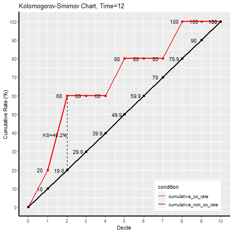

## Gini Curve/Lorenz Curve

Gini–Area under Gini Curve/Lorenz Curve of model as compared to the perfect model, or one that would capture 100% of events in the first score bucket / decile. Values ranging from 0-1.

$$Gini=2×ROC-1$$

Pietra Index–The maximum vertical distance between the model Lorenz Curve and the line representing a random decision rule. This distance may be interpreted as the maximum ‘lift’ over random provided by the model.

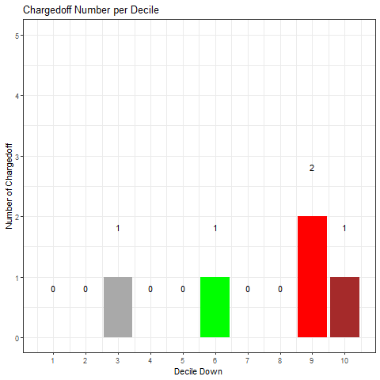

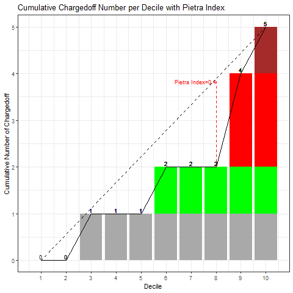

## ROC Curve

ROC (Receiver Operating Characteristic) curve is a performance measurement for classification problem at various thresholds settings. AUC - Area Under the Curve.

### 12

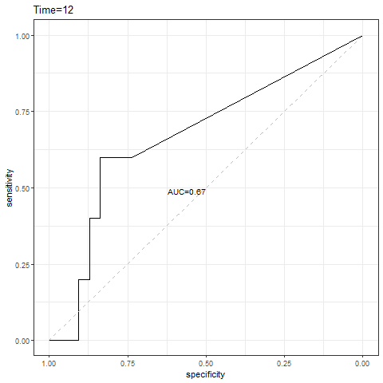

### 1-29

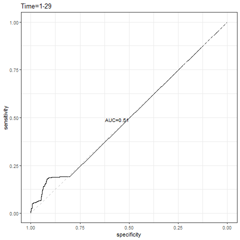

# PD Backtesting by Bucket

## Time Point

### Time

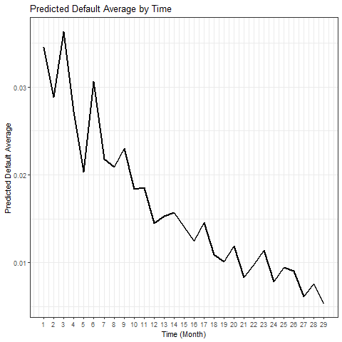

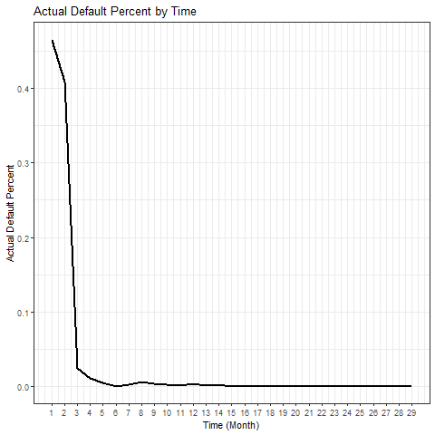

### Deposit Segment

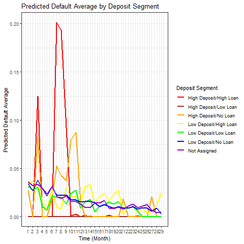

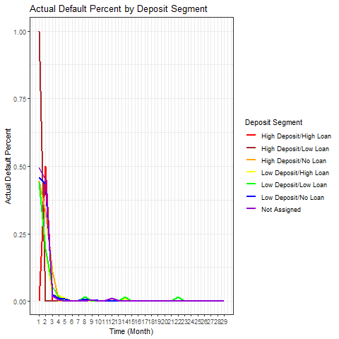

### Ever Modified Flag

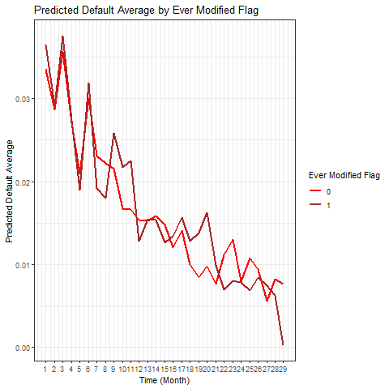

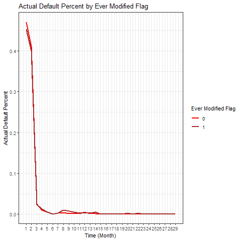

### Generation

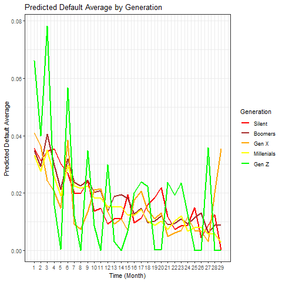

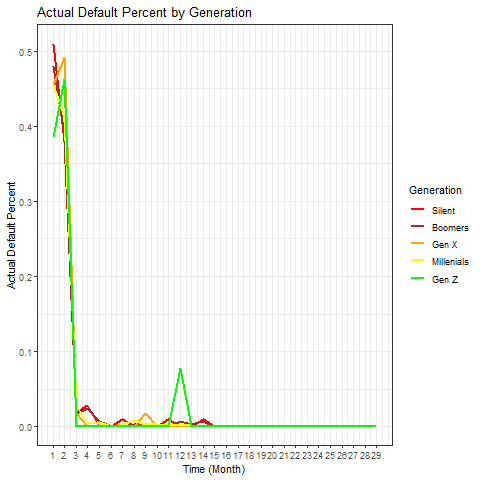

### Military Group

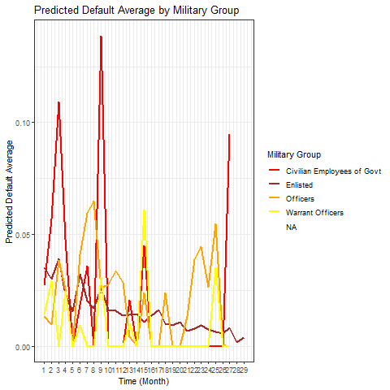

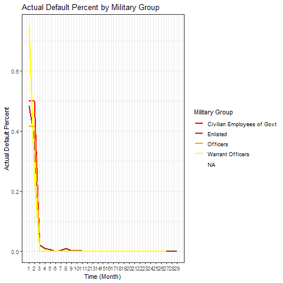

### Last Status

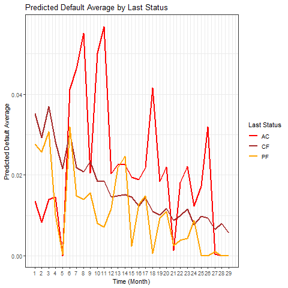

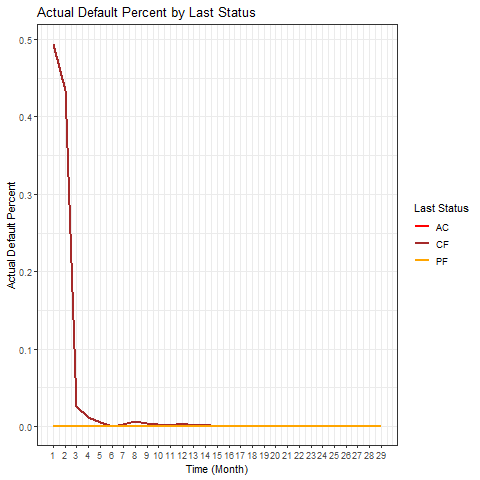

### Length of Membership Bucketed

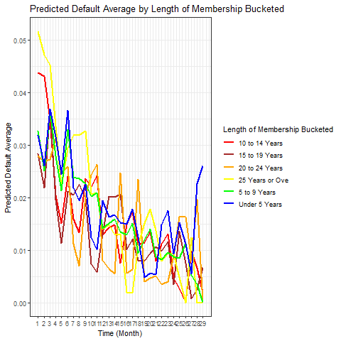

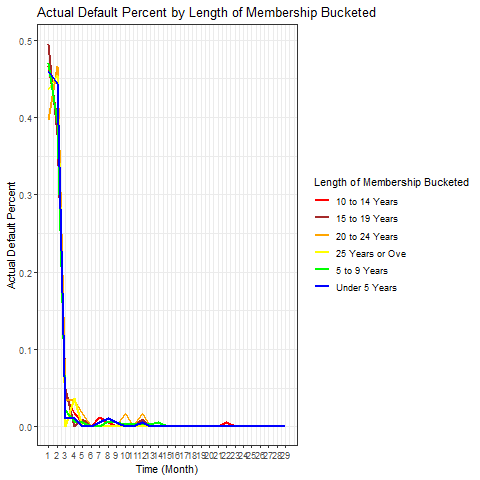

### Estimated Income (factor)

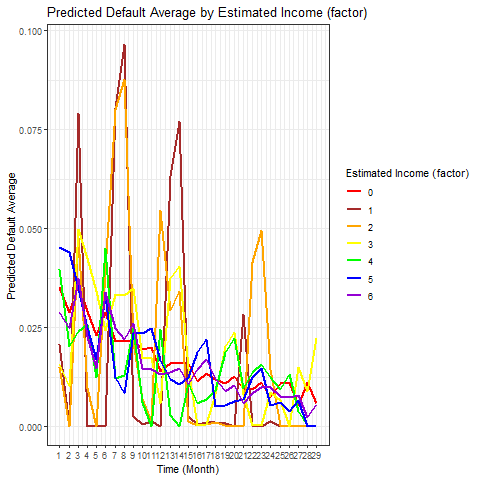

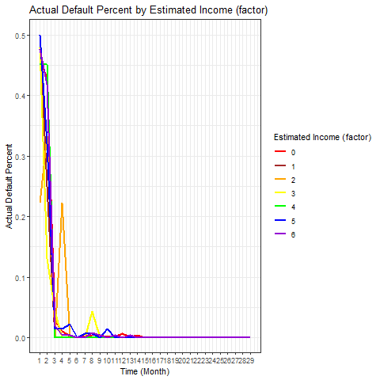

### <6 Months Membership

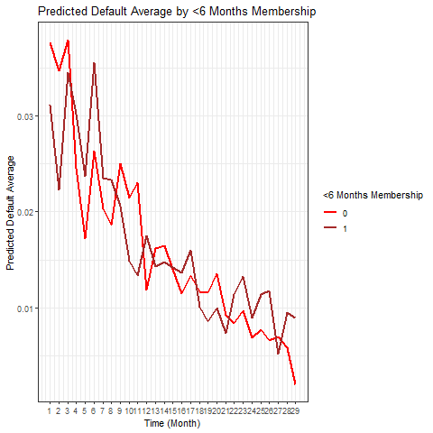

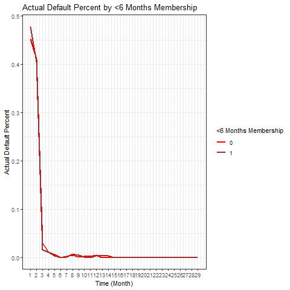

### Origin Group

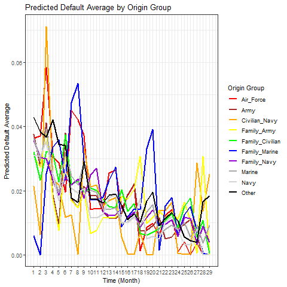

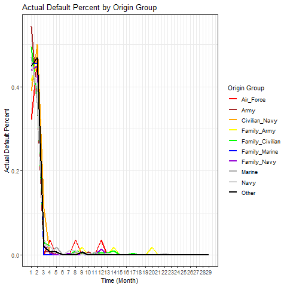

### Product Bucket

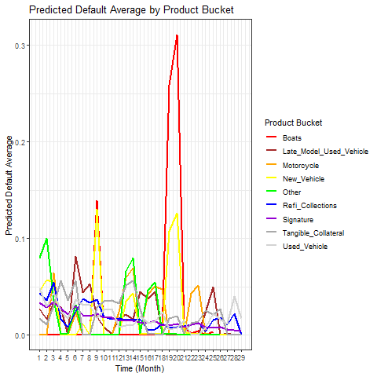

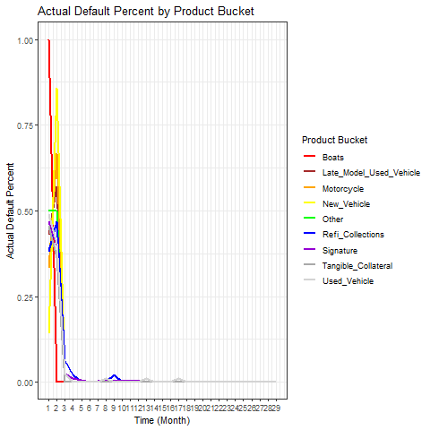

### Product Group

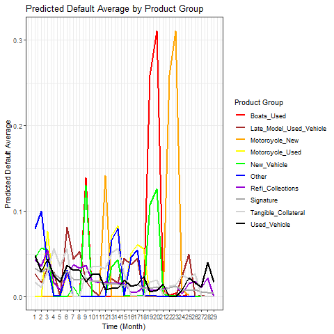

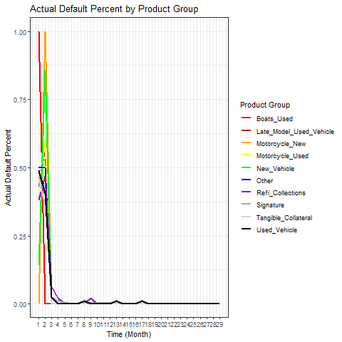

### Final Status

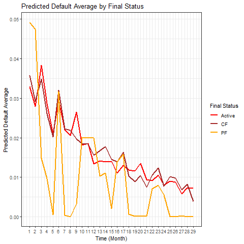

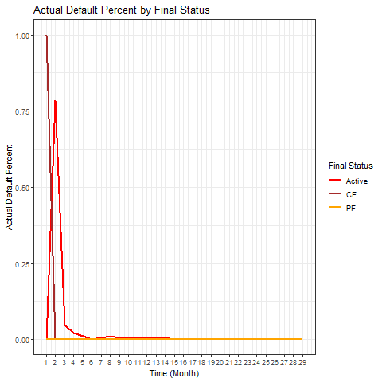

### Origination Term

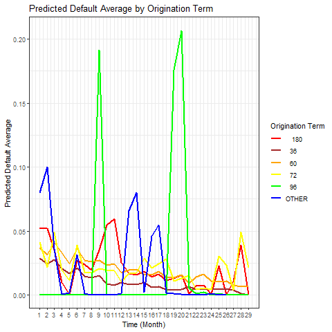

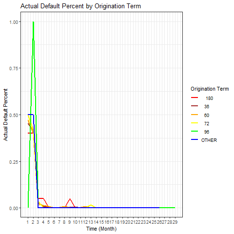

### Original Tier

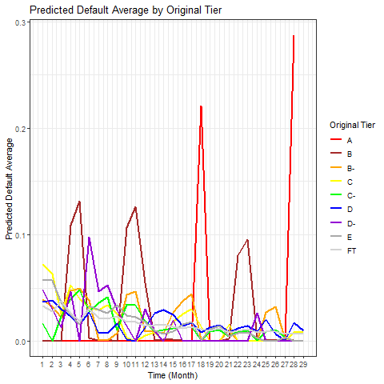

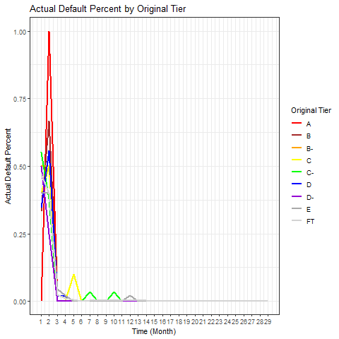

### Snapshot Tier

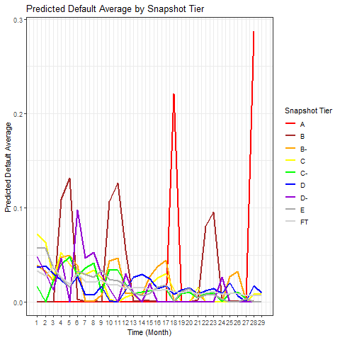

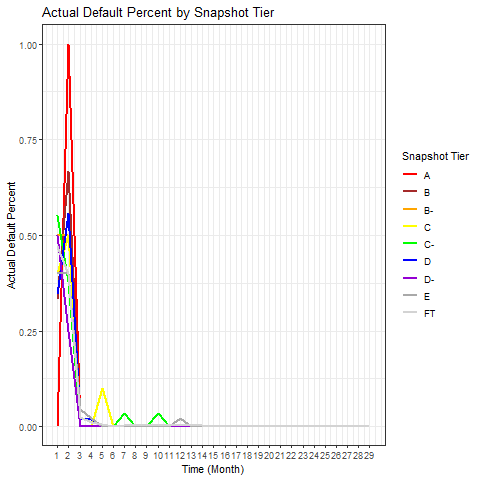

## Aggregate

### Deposit Segment

| Dep_Loan_Seg_Desc | Predicted Default Average | Predicted Default Sum | Default Number | Account Number | Percent of Default | Predicted Default Error Rate |
| --- | --- | --- | --- | --- | --- | --- |
| Not Assigned | 0.0171 | 138.15 | 302 | 304 | 0.9934 | -54.25 |
| Low Deposit/No Loan | 0.0173 | 319.73 | 671 | 696 | 0.9641 | -52.35 |
| Low Deposit/Low Loan | 0.0147 | 22.03 | 43 | 57 | 0.7544 | -48.77 |
| Low Deposit/High Loan | 0.0189 | 45.90 | 65 | 91 | 0.7143 | -29.38 |
| High Deposit/High Loan | 0.0254 | 1.24 | 1 | 2 | 0.5000 | 24.32 |
| High Deposit/No Loan | 0.0179 | 4.31 | 8 | 9 | 0.8889 | -46.09 |
| High Deposit/Low Loan | 0.0000 | 0.00 | 1 | 1 | 1.0000 | -100.00 |

### Ever Modified Flag

| Ever.Mod | Predicted Default Average | Predicted Default Sum | Default Number | Account Number | Percent of Default | Predicted Default Error Rate |
| --- | --- | --- | --- | --- | --- | --- |
| 0 | 0.0171 | 353.88 | 734 | 780 | 0.9410 | -51.79 |
| 1 | 0.0176 | 177.49 | 357 | 380 | 0.9395 | -50.28 |

### Generation

| Generation | Predicted Default Average | Predicted Default Sum | Default Number | Account Number | Percent of Default | Predicted Default Error Rate |
| --- | --- | --- | --- | --- | --- | --- |
| Boomers | 0.0181 | 51.15 | 104 | 108 | 0.9630 | -50.82 |
| Gen X | 0.0186 | 142.52 | 272 | 288 | 0.9444 | -47.60 |
| Millenials | 0.0166 | 308.05 | 649 | 696 | 0.9325 | -52.54 |
| Silent | 0.0198 | 6.59 | 12 | 13 | 0.9231 | -45.04 |
| Gen Z | 0.0158 | 23.06 | 54 | 55 | 0.9818 | -57.29 |

### Military Group

| IND_Military_Group_Desc | Predicted Default Average | Predicted Default Sum | Default Number | Account Number | Percent of Default | Predicted Default Error Rate |
| --- | --- | --- | --- | --- | --- | --- |
| Enlisted | 0.0163 | 196.55 | 420 | 452 | 0.9292 | -53.20 |
| NA | 0.0178 | 325.91 | 655 | 690 | 0.9493 | -50.24 |
| Warrant Officers | 0.0083 | 0.86 | 4 | 4 | 1.0000 | -78.50 |
| Officers | 0.0231 | 6.94 | 10 | 12 | 0.8333 | -30.61 |
| Civilian Employees of Govt | 0.0207 | 1.10 | 2 | 2 | 1.0000 | -45.17 |

### Last Status

| last_status | Predicted Default Average | Predicted Default Sum | Default Number | Account Number | Percent of Default | Predicted Default Error Rate |
| --- | --- | --- | --- | --- | --- | --- |
| CF | 0.0175 | 505.36 | 1091 | 1091 | 1 | -53.68 |
| PF | 0.0117 | 17.37 | 0 | 55 | 0 | 1636.69 |
| AC | 0.0235 | 8.63 | 0 | 14 | 0 | 763.45 |

### Length of Membership Bucketed

| Length_Of_Mbrshp_Range | Predicted Default Average | Predicted Default Sum | Default Number | Account Number | Percent of Default | Predicted Default Error Rate |
| --- | --- | --- | --- | --- | --- | --- |
| 25 Years or Ove | 0.0197 | 28.68 | 51 | 55 | 0.9273 | -43.77 |
| 20 to 24 Years | 0.0151 | 23.14 | 57 | 58 | 0.9828 | -59.41 |
| 15 to 19 Years | 0.0148 | 40.34 | 97 | 103 | 0.9417 | -58.41 |
| 10 to 14 Years | 0.0167 | 78.69 | 167 | 176 | 0.9489 | -52.88 |
| 5 to 9 Years | 0.0175 | 266.29 | 533 | 572 | 0.9318 | -50.04 |
| Under 5 Years | 0.0181 | 94.23 | 186 | 196 | 0.9490 | -49.34 |

### Estimated Income (factor)

| Member_Estimated_Income | Predicted Default Average | Predicted Default Sum | Default Number | Account Number | Percent of Default | Predicted Default Error Rate |
| --- | --- | --- | --- | --- | --- | --- |
| 0 | 0.0177 | 334.99 | 686 | 715 | 0.9594 | -51.17 |
| 5 | 0.0170 | 60.43 | 121 | 134 | 0.9030 | -50.06 |
| 6 | 0.0162 | 105.41 | 230 | 244 | 0.9426 | -54.17 |
| 4 | 0.0150 | 12.25 | 28 | 31 | 0.9032 | -56.25 |
| 3 | 0.0187 | 11.64 | 16 | 23 | 0.6957 | -27.28 |
| 2 | 0.0204 | 4.83 | 7 | 9 | 0.7778 | -31.05 |
| 1 | 0.0174 | 1.83 | 3 | 4 | 0.7500 | -39.05 |

### <6 Months Membership

| New.Member | Predicted Default Average | Predicted Default Sum | Default Number | Account Number | Percent of Default | Predicted Default Error Rate |
| --- | --- | --- | --- | --- | --- | --- |
| 0 | 0.0173 | 282.05 | 578 | 616 | 0.9383 | -51.2 |
| 1 | 0.0172 | 249.31 | 513 | 544 | 0.9430 | -51.4 |

### Origin Group

| origin_group | Predicted Default Average | Predicted Default Sum | Default Number | Account Number | Percent of Default | Predicted Default Error Rate |
| --- | --- | --- | --- | --- | --- | --- |
| Navy | 0.0153 | 81.39 | 190 | 202 | 0.9406 | -57.16 |
| Family_Navy | 0.0170 | 92.88 | 195 | 207 | 0.9420 | -52.37 |
| Air_Force | 0.0205 | 15.23 | 25 | 28 | 0.8929 | -39.10 |
| Army | 0.0160 | 54.68 | 119 | 127 | 0.9370 | -54.05 |
| Marine | 0.0173 | 74.04 | 146 | 160 | 0.9125 | -49.29 |
| Family_Army | 0.0168 | 23.58 | 49 | 53 | 0.9245 | -51.88 |
| Civilian_Navy | 0.0142 | 6.73 | 18 | 18 | 1.0000 | -62.63 |
| Family_Civilian | 0.0179 | 92.86 | 188 | 196 | 0.9592 | -50.61 |
| Other | 0.0200 | 77.91 | 141 | 147 | 0.9592 | -44.74 |
| Family_Marine | 0.0204 | 12.07 | 20 | 22 | 0.9091 | -39.63 |

### Product Bucket

| Product.Bucket | Predicted Default Average | Predicted Default Sum | Default Number | Account Number | Percent of Default | Predicted Default Error Rate |
| --- | --- | --- | --- | --- | --- | --- |
| Refi_Collections | 0.0191 | 23.61 | 45 | 47 | 0.9574 | -47.53 |
| Signature | 0.0168 | 443.70 | 932 | 993 | 0.9386 | -52.39 |
| Used_Vehicle | 0.0196 | 43.44 | 80 | 84 | 0.9524 | -45.70 |
| Late_Model_Used_Vehicle | 0.0219 | 3.95 | 7 | 7 | 1.0000 | -43.60 |
| Motorcycle | 0.0182 | 2.90 | 6 | 6 | 1.0000 | -51.75 |
| New_Vehicle | 0.0240 | 4.37 | 7 | 7 | 1.0000 | -37.61 |
| Tangible_Collateral | 0.0227 | 6.65 | 9 | 11 | 0.8182 | -26.13 |
| Other | 0.0201 | 2.03 | 4 | 4 | 1.0000 | -49.28 |
| Boats | 0.0291 | 0.73 | 1 | 1 | 1.0000 | -27.35 |

### Product Group

| Product_Group | Predicted Default Average | Predicted Default Sum | Default Number | Account Number | Percent of Default | Predicted Default Error Rate |
| --- | --- | --- | --- | --- | --- | --- |
| Refi_Collections | 0.0191 | 23.61 | 45 | 47 | 0.9574 | -47.53 |
| Signature | 0.0168 | 443.70 | 932 | 993 | 0.9386 | -52.39 |
| Used_Vehicle | 0.0196 | 43.44 | 80 | 84 | 0.9524 | -45.70 |
| Late_Model_Used_Vehicle | 0.0219 | 3.95 | 7 | 7 | 1.0000 | -43.60 |
| Motorcycle_Used | 0.0162 | 2.17 | 5 | 5 | 1.0000 | -56.52 |
| New_Vehicle | 0.0240 | 4.37 | 7 | 7 | 1.0000 | -37.61 |
| Tangible_Collateral | 0.0227 | 6.65 | 9 | 11 | 0.8182 | -26.13 |
| Other | 0.0201 | 2.03 | 4 | 4 | 1.0000 | -49.28 |
| Boats_Used | 0.0291 | 0.73 | 1 | 1 | 1.0000 | -27.35 |
| Motorcycle_New | 0.0289 | 0.72 | 1 | 1 | 1.0000 | -27.87 |

### Final Status

| Status | Predicted Default Average | Predicted Default Sum | Default Number | Account Number | Percent of Default | Predicted Default Error Rate |
| --- | --- | --- | --- | --- | --- | --- |
| Active | 0.0173 | 275.52 | 552 | 602 | 0.9169 | -50.09 |
| CF | 0.0175 | 250.29 | 539 | 539 | 1.0000 | -53.56 |
| PF | 0.0107 | 5.55 | 0 | 19 | 0.0000 | 455.24 |

### Origination Term

| Term | Predicted Default Average | Predicted Default Sum | Default Number | Account Number | Percent of Default | Predicted Default Error Rate |
| --- | --- | --- | --- | --- | --- | --- |
| 180 | 0.0218 | 11.55 | 19 | 20 | 0.9500 | -39.21 |
| 60 | 0.0209 | 359.81 | 613 | 648 | 0.9460 | -41.30 |
| 72 | 0.0204 | 32.45 | 58 | 60 | 0.9667 | -44.04 |
| 36 | 0.0110 | 124.35 | 395 | 426 | 0.9272 | -68.52 |
| 96 | 0.0212 | 1.17 | 2 | 2 | 1.0000 | -41.57 |
| OTHER | 0.0201 | 2.03 | 4 | 4 | 1.0000 | -49.28 |

### Original Tier

| TIER | Predicted Default Average | Predicted Default Sum | Default Number | Account Number | Percent of Default | Predicted Default Error Rate |
| --- | --- | --- | --- | --- | --- | --- |
| FT | 0.0172 | 454.01 | 940 | 1000 | 0.9400 | -51.70 |
| E | 0.0185 | 22.22 | 40 | 45 | 0.8889 | -44.45 |
| D | 0.0164 | 23.54 | 49 | 52 | 0.9423 | -51.97 |
| C | 0.0180 | 5.12 | 10 | 10 | 1.0000 | -48.77 |
| C- | 0.0160 | 13.29 | 29 | 29 | 1.0000 | -54.17 |
| B- | 0.0186 | 8.64 | 16 | 16 | 1.0000 | -46.01 |
| D- | 0.0179 | 1.87 | 3 | 4 | 0.7500 | -37.78 |
| B | 0.0250 | 2.17 | 3 | 3 | 1.0000 | -27.57 |
| A | 0.0182 | 0.51 | 1 | 1 | 1.0000 | -49.14 |

### Snapshot Tier

| Tier.SS | Predicted Default Average | Predicted Default Sum | Default Number | Account Number | Percent of Default | Predicted Default Error Rate |
| --- | --- | --- | --- | --- | --- | --- |
| FT | 0.0172 | 454.01 | 940 | 1000 | 0.9400 | -51.70 |
| E | 0.0185 | 22.22 | 40 | 45 | 0.8889 | -44.45 |
| D | 0.0164 | 23.54 | 49 | 52 | 0.9423 | -51.97 |
| C | 0.0180 | 5.12 | 10 | 10 | 1.0000 | -48.77 |
| C- | 0.0160 | 13.29 | 29 | 29 | 1.0000 | -54.17 |
| B- | 0.0186 | 8.64 | 16 | 16 | 1.0000 | -46.01 |
| D- | 0.0179 | 1.87 | 3 | 4 | 0.7500 | -37.78 |
| B | 0.0250 | 2.17 | 3 | 3 | 1.0000 | -27.57 |
| A | 0.0182 | 0.51 | 1 | 1 | 1.0000 | -49.14 |

## PD Final

| Predicted Default Average | Predicted Default Sum | Default Number | Account Number | Percent of Default | Predicted Default Error Rate |
| --- | --- | --- | --- | --- | --- |
| 0.0173 | 531.36 | 1091 | 1160 | 0.9405 | -51.3 |

# Loss Forecast Backtesting

## Time Point

### Time

| Time | Number of Accounts | Number of Chargedoff Accounts | Preded Losses | Actual Losses | Loss Error Rate |
| --- | --- | --- | --- | --- | --- |
| 1 | 1160 | 539 | 394150.16 | 4192907.77 | -0.9060 |
| 2 | 1160 | 473 | 337260.63 | 3895306.52 | -0.9134 |
| 3 | 1160 | 28 | 379178.31 | 194083.74 | 0.9537 |
| 4 | 1160 | 13 | 249567.65 | 115509.84 | 1.1606 |
| 5 | 1160 | 6 | 183990.70 | 37306.89 | 3.9318 |
| 6 | 1160 | 0 | 229436.08 | 0.00 | Inf |
| 7 | 1160 | 3 | 194603.60 | 13153.32 | 13.7950 |
| 8 | 1160 | 7 | 192306.21 | 41685.25 | 3.6133 |
| 9 | 1160 | 4 | 200011.86 | 41740.18 | 3.7918 |
| 10 | 1160 | 3 | 173684.30 | 32174.60 | 4.3982 |
| 11 | 1160 | 2 | 178516.93 | 13395.44 | 12.3267 |
| 12 | 1160 | 5 | 118004.60 | 37725.02 | 2.1280 |
| 13 | 1160 | 2 | 120256.13 | 30440.87 | 2.9505 |
| 14 | 1160 | 3 | 116772.37 | 26535.65 | 3.4006 |
| 15 | 1160 | 0 | 129105.92 | 0.00 | Inf |
| 16 | 1160 | 0 | 92059.06 | 0.00 | Inf |
| 17 | 1160 | 1 | 109116.75 | 1317.00 | 81.8525 |
| 18 | 1160 | 0 | 105195.23 | 0.00 | Inf |
| 19 | 1160 | 0 | 79051.40 | 0.00 | Inf |
| 20 | 1160 | 1 | 89031.09 | 7757.55 | 10.4767 |
| 21 | 1160 | 0 | 63528.89 | 0.00 | Inf |
| 22 | 1160 | 1 | 66942.97 | 6150.00 | 9.8850 |
| 23 | 1160 | 0 | 84063.09 | 0.00 | Inf |
| 24 | 1160 | 0 | 38380.96 | 0.00 | Inf |
| 25 | 968 | 0 | 77937.85 | 0.00 | Inf |
| 26 | 792 | 0 | 50588.82 | 0.00 | Inf |
| 27 | 606 | 0 | 17294.40 | 0.00 | Inf |
| 28 | 405 | 0 | 32398.97 | 0.00 | Inf |
| 29 | 191 | 0 | 10689.68 | 0.00 | Inf |

### Deposit Segment

| Dep_Loan_Seg_Desc | Number of Accounts | Number of Chargedoff Accounts | Preded Losses | Actual Losses | Loss Error Rate |
| --- | --- | --- | --- | --- | --- |
| High Deposit/High Loan | 2 | 1 | 9208.759 | 10846.56 | -0.1510 |
| High Deposit/Low Loan | 1 | 1 | 0.000 | 504.01 | -1.0000 |
| High Deposit/No Loan | 9 | 8 | 30745.776 | 71105.60 | -0.5676 |
| Low Deposit/High Loan | 91 | 65 | 350209.314 | 537169.35 | -0.3480 |
| Low Deposit/Low Loan | 57 | 43 | 164772.902 | 300117.33 | -0.4510 |
| Low Deposit/No Loan | 696 | 671 | 2547507.099 | 5589772.01 | -0.5443 |
| Not Assigned | 304 | 302 | 1010680.764 | 2177674.78 | -0.5359 |

### Ever Modified Flag

| Ever.Mod | Number of Accounts | Number of Chargedoff Accounts | Preded Losses | Actual Losses | Loss Error Rate |
| --- | --- | --- | --- | --- | --- |
| 0 | 780 | 734 | 2560553 | 5384674 | -0.5245 |
| 1 | 380 | 357 | 1552572 | 3302516 | -0.5299 |

### Generation

| Generation | Number of Accounts | Number of Chargedoff Accounts | Preded Losses | Actual Losses | Loss Error Rate |
| --- | --- | --- | --- | --- | --- |
| Silent | 13 | 12 | 52017.05 | 124842.6 | -0.5833 |
| Boomers | 108 | 104 | 554910.64 | 1132194.5 | -0.5099 |
| Gen X | 288 | 272 | 1291808.54 | 2823778.8 | -0.5425 |
| Millenials | 696 | 649 | 2116865.45 | 4390892.5 | -0.5179 |
| Gen Z | 55 | 54 | 97522.94 | 215481.3 | -0.5474 |

### Military Group

| IND_Military_Group_Desc | Number of Accounts | Number of Chargedoff Accounts | Preded Losses | Actual Losses | Loss Error Rate |
| --- | --- | --- | --- | --- | --- |
| Civilian Employees of Govt | 2 | 2 | 9969.866 | 22227.36 | -0.5515 |
| Enlisted | 452 | 420 | 1302669.689 | 2797714.99 | -0.5344 |
| Officers | 12 | 10 | 87749.674 | 183894.13 | -0.5228 |
| Warrant Officers | 4 | 4 | 4426.035 | 32113.96 | -0.8622 |
| NA | 690 | 655 | 2708309.350 | 5651239.20 | -0.5208 |

### Last Status

| last_status | Number of Accounts | Number of Chargedoff Accounts | Preded Losses | Actual Losses | Loss Error Rate |
| --- | --- | --- | --- | --- | --- |
| AC | 14 | 0 | 59508.37 | 0 | Inf |
| CF | 1091 | 1091 | 3966791.40 | 8687190 | -0.5434 |
| PF | 55 | 0 | 86824.85 | 0 | Inf |

### Length of Membership Bucketed

| Length_Of_Mbrshp_Range | Number of Accounts | Number of Chargedoff Accounts | Preded Losses | Actual Losses | Loss Error Rate |
| --- | --- | --- | --- | --- | --- |
| 10 to 14 Years | 176 | 167 | 626578.7 | 1244443.7 | -0.4965 |
| 15 to 19 Years | 103 | 97 | 345611.6 | 791772.3 | -0.5635 |
| 20 to 24 Years | 58 | 57 | 203075.6 | 505427.4 | -0.5982 |
| 25 Years or Ove | 55 | 51 | 284411.1 | 594863.6 | -0.5219 |
| 5 to 9 Years | 572 | 533 | 1830910.4 | 3843797.3 | -0.5237 |
| Under 5 Years | 196 | 186 | 822537.1 | 1706885.4 | -0.5181 |

### Estimated Income (factor)

| Member_Estimated_Income | Number of Accounts | Number of Chargedoff Accounts | Preded Losses | Actual Losses | Loss Error Rate |
| --- | --- | --- | --- | --- | --- |
| 0 | 715 | 686 | 2813726.011 | 5913732.76 | -0.5242 |
| 1 | 4 | 3 | 8344.911 | 11234.77 | -0.2572 |
| 2 | 9 | 7 | 48450.416 | 88851.16 | -0.4547 |
| 3 | 23 | 16 | 89605.946 | 147161.68 | -0.3911 |
| 4 | 31 | 28 | 121626.003 | 317982.52 | -0.6175 |
| 5 | 134 | 121 | 454168.919 | 933248.92 | -0.5133 |
| 6 | 244 | 230 | 577202.407 | 1274977.83 | -0.5473 |

### <6 Months Membership

| New.Member | Number of Accounts | Number of Chargedoff Accounts | Preded Losses | Actual Losses | Loss Error Rate |
| --- | --- | --- | --- | --- | --- |
| 0 | 616 | 578 | 2239491 | 4664995 | -0.5199 |
| 1 | 544 | 513 | 1873634 | 4022194 | -0.5342 |

### Origin Group

| origin_group | Number of Accounts | Number of Chargedoff Accounts | Preded Losses | Actual Losses | Loss Error Rate |
| --- | --- | --- | --- | --- | --- |
| Air_Force | 28 | 25 | 107570.99 | 189499.4 | -0.4323 |
| Army | 127 | 119 | 358251.19 | 808081.7 | -0.5567 |
| Civilian_Navy | 18 | 18 | 61266.04 | 141447.1 | -0.5669 |
| Family_Army | 53 | 49 | 176373.24 | 446296.0 | -0.6048 |
| Family_Civilian | 196 | 188 | 758973.26 | 1567347.8 | -0.5158 |
| Family_Marine | 22 | 20 | 98283.58 | 193516.9 | -0.4921 |
| Family_Navy | 207 | 195 | 731145.14 | 1486580.1 | -0.5082 |
| Marine | 160 | 146 | 463699.59 | 976649.7 | -0.5252 |
| Navy | 202 | 190 | 628903.91 | 1384312.5 | -0.5457 |
| Other | 147 | 141 | 728657.67 | 1493458.4 | -0.5121 |

### Product Bucket

| Product.Bucket | Number of Accounts | Number of Chargedoff Accounts | Preded Losses | Actual Losses | Loss Error Rate |
| --- | --- | --- | --- | --- | --- |
| Boats | 1 | 1 | 13334.658 | 26808.86 | -0.5026 |
| Late_Model_Used_Vehicle | 7 | 7 | 63893.704 | 147384.70 | -0.5665 |
| Motorcycle | 6 | 6 | 20567.590 | 48098.82 | -0.5724 |
| New_Vehicle | 7 | 7 | 81091.215 | 159701.59 | -0.4922 |
| Other | 4 | 4 | 4909.858 | 21201.46 | -0.7684 |
| Refi_Collections | 47 | 45 | 179704.372 | 351832.29 | -0.4892 |
| Signature | 993 | 932 | 3241691.086 | 6787750.90 | -0.5224 |
| Tangible_Collateral | 11 | 9 | 65137.602 | 117707.38 | -0.4466 |
| Used_Vehicle | 84 | 80 | 442794.530 | 1026703.64 | -0.5687 |

### Product Group

| Product_Group | Number of Accounts | Number of Chargedoff Accounts | Preded Losses | Actual Losses | Loss Error Rate |
| --- | --- | --- | --- | --- | --- |
| Boats_Used | 1 | 1 | 13334.658 | 26808.86 | -0.5026 |
| Late_Model_Used_Vehicle | 7 | 7 | 63893.704 | 147384.70 | -0.5665 |
| Motorcycle_New | 1 | 1 | 8291.219 | 18816.24 | -0.5594 |
| Motorcycle_Used | 5 | 5 | 12276.372 | 29282.58 | -0.5808 |
| New_Vehicle | 7 | 7 | 81091.215 | 159701.59 | -0.4922 |
| Other | 4 | 4 | 4909.858 | 21201.46 | -0.7684 |
| Refi_Collections | 47 | 45 | 179704.372 | 351832.29 | -0.4892 |
| Signature | 993 | 932 | 3241691.086 | 6787750.90 | -0.5224 |
| Tangible_Collateral | 11 | 9 | 65137.602 | 117707.38 | -0.4466 |
| Used_Vehicle | 84 | 80 | 442794.530 | 1026703.64 | -0.5687 |

### Final Status

| Status | Number of Accounts | Number of Chargedoff Accounts | Preded Losses | Actual Losses | Loss Error Rate |
| --- | --- | --- | --- | --- | --- |
| Active | 602 | 552 | 2149530.2 | 4494282 | -0.5217 |
| CF | 539 | 539 | 1930604.6 | 4192908 | -0.5396 |
| PF | 19 | 0 | 32989.8 | 0 | Inf |

### Origination Term

| Term | Number of Accounts | Number of Chargedoff Accounts | Preded Losses | Actual Losses | Loss Error Rate |
| --- | --- | --- | --- | --- | --- |
| 180 | 20 | 19 | 170658.501 | 332694.92 | -0.4870 |
| 36 | 426 | 395 | 411783.383 | 1048567.24 | -0.6073 |
| 60 | 648 | 613 | 3114852.284 | 6310190.40 | -0.5064 |
| 72 | 60 | 58 | 399279.182 | 945988.03 | -0.5779 |
| 96 | 2 | 2 | 11641.406 | 28547.59 | -0.5922 |
| OTHER | 4 | 4 | 4909.858 | 21201.46 | -0.7684 |

### Original Tier

| TIER | Number of Accounts | Number of Chargedoff Accounts | Preded Losses | Actual Losses | Loss Error Rate |
| --- | --- | --- | --- | --- | --- |
| A | 1 | 1 | 7409.748 | 23309.47 | -0.6821 |
| B | 3 | 3 | 11548.855 | 23507.51 | -0.5087 |
| B- | 16 | 16 | 81910.155 | 171655.01 | -0.5228 |
| C | 10 | 10 | 56649.390 | 105657.57 | -0.4638 |
| C- | 29 | 29 | 104285.188 | 200132.70 | -0.4789 |
| D | 52 | 49 | 223270.993 | 511704.13 | -0.5637 |
| D- | 4 | 3 | 11916.209 | 23581.45 | -0.4947 |
| E | 45 | 40 | 187466.067 | 357311.85 | -0.4753 |
| FT | 1000 | 940 | 3428668.007 | 7270329.95 | -0.5284 |

### Snapshot Tier

| Tier.SS | Number of Accounts | Number of Chargedoff Accounts | Preded Losses | Actual Losses | Loss Error Rate |
| --- | --- | --- | --- | --- | --- |
| A | 1 | 1 | 7409.748 | 23309.47 | -0.6821 |
| B | 3 | 3 | 11548.855 | 23507.51 | -0.5087 |
| B- | 16 | 16 | 81910.155 | 171655.01 | -0.5228 |
| C | 10 | 10 | 56649.390 | 105657.57 | -0.4638 |
| C- | 29 | 29 | 104285.188 | 200132.70 | -0.4789 |
| D | 52 | 49 | 223270.993 | 511704.13 | -0.5637 |
| D- | 4 | 3 | 11916.209 | 23581.45 | -0.4947 |
| E | 45 | 40 | 187466.067 | 357311.85 | -0.4753 |
| FT | 1000 | 940 | 3428668.007 | 7270329.95 | -0.5284 |

## Aggregate Loss

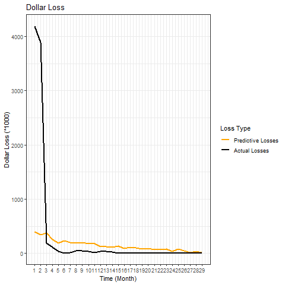

## Loss Error Rate

| Number of Accounts | AUC | Preded Losses | Actual Losses | Loss Error Rate |
| --- | --- | --- | --- | --- |
| 1160 | 0.51 | 4113125 | 8687190 | -0.5265 |